# BA12 Knn_new

#### KNN

```python
import pandas as pd
from sklearn import preprocessing
from sklearn.model_selection import train_test_split
from sklearn.metrics import accuracy_score
from sklearn.neighbors import NearestNeighbors, KNeighborsClassifier
import matplotlib.pylab as plt
```

##### Example: Riding Mowers

A riding-mower manufacturer would like to find a way of classifying families in a city into those likely to purchase a riding mower and those not likely to buy one. A pilot random sample is undertaken of 12 owners and 12 nonowners in the city. First partition the data into training data (14 households) and validation data (10 households). Obviously, this dataset is too small for partitioning, which can result in unstable results, but we will continue with this partitioning for illustration purposes. First as usual EDA- draw a scatter plot of the training data.

```python
mower_df = pd.read_csv('E:/2020_Classes/BA/datasets/RidingMowers.csv')
```

```python
# Income in Thousand dollars and Lot_size in Thousand Sq feet
mower_df.head(4)
```

|  | Income | Lot_Size | Ownership | Number |
| --- | --- | --- | --- | --- |
| 0 | 60.0 | 18.4 | Owner | 1 |
| 1 | 85.5 | 16.8 | Owner | 2 |
| 2 | 64.8 | 21.6 | Owner | 3 |
| 3 | 61.5 | 20.8 | Owner | 4 |

```python
mower_df['Number'] = mower_df.index + 1
mower_df.head
```

```
<bound method NDFrame.head of     Income  Lot_Size Ownership  Number
0     60.0      18.4     Owner       1
1     85.5      16.8     Owner       2
2     64.8      21.6     Owner       3
3     61.5      20.8     Owner       4
4     87.0      23.6     Owner       5
5    110.1      19.2     Owner       6
6    108.0      17.6     Owner       7
7     82.8      22.4     Owner       8
8     69.0      20.0     Owner       9
9     93.0      20.8     Owner      10
10    51.0      22.0     Owner      11
11    81.0      20.0     Owner      12
12    75.0      19.6  Nonowner      13
13    52.8      20.8  Nonowner      14
14    64.8      17.2  Nonowner      15
15    43.2      20.4  Nonowner      16
16    84.0      17.6  Nonowner      17
17    49.2      17.6  Nonowner      18
18    59.4      16.0  Nonowner      19
19    66.0      18.4  Nonowner      20
20    47.4      16.4  Nonowner      21
21    33.0      18.8  Nonowner      22
22    51.0      14.0  Nonowner      23
23    63.0      14.8  Nonowner      24>
```

```python
mower_df['Number'].head(2)
```

```
0    1
1    2
Name: Number, dtype: int64
```

```python
trainData, validData = train_test_split(mower_df, test_size=0.4,random_state=26)
```

```python
trainData.head(2)
```

|  | Income | Lot_Size | Ownership | Number |
| --- | --- | --- | --- | --- |
| 5 | 110.1 | 19.2 | Owner | 6 |
| 3 | 61.5 | 20.8 | Owner | 4 |

Among the households in the training set, the one closest to the new household (in Euclidean distance after normalizing income and lot size) is household 4,with $61,500 income and lot size 20,800 ft2. If we use a 1-NN classifier, we would classify the new household as an owner, like household 4.

If we use k = 3, the three nearest households are 4, 14, and 1, as can be seen visually in the scatter plot, and as computed. Two of these neighbors are owners of riding mowers, and one is a nonowner. The majority vote is therefore owner, and the new household would be classified as an owner.

```python
## new household Income 60,000 dollars and lot size 20,000 sq ft
newHousehold = pd.DataFrame([{'Income': 60, 'Lot_Size': 20}])
```

```python
import matplotlib.pyplot as plt
```

```python
m = mower_df
```

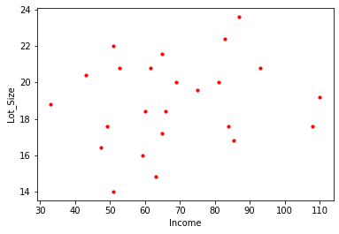

```python
plt.scatter(m.Income, m.Lot_Size,s=10, c="r")
plt.xlabel('Income') # set x-axis label
plt.ylabel('Lot_Size') # set y-axis label
```

```python
m = trainData
sub_train_owner = m.loc[m['Ownership']=='Owner']
sub_train_mnon = m.loc[m['Ownership']=='Nonowner']
```

```python
sub_train_owner
```

|  | Income | Lot_Size | Ownership | Number |
| --- | --- | --- | --- | --- |
| 5 | 110.1 | 19.2 | Owner | 6 |
| 3 | 61.5 | 20.8 | Owner | 4 |
| 7 | 82.8 | 22.4 | Owner | 8 |
| 2 | 64.8 | 21.6 | Owner | 3 |
| 4 | 87.0 | 23.6 | Owner | 5 |
| 0 | 60.0 | 18.4 | Owner | 1 |
| 1 | 85.5 | 16.8 | Owner | 2 |
| 6 | 108.0 | 17.6 | Owner | 7 |

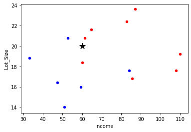

```python
plt.scatter(sub_train_owner.Income, sub_train_owner.Lot_Size, s=20, color ='red')
plt.scatter(sub_train_mnon.Income, sub_train_mnon.Lot_Size, s=20, color ='blue')
plt.xlabel('Income') # set x-axis label
plt.ylabel('Lot_Size') # set y-axis label
plt.scatter(newHousehold.Income, newHousehold.Lot_Size, marker='*',color='black', s=150)
```

```python
m2 = validData
sub_valid_owner = m2.loc[m2['Ownership']=='Owner']
sub_valid_mnon = m2.loc[m2['Ownership']=='Nonowner']
```

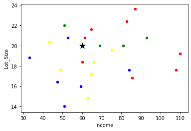

```python
plt.scatter(sub_train_owner.Income, sub_train_owner.Lot_Size, s=20, color ='red')
plt.scatter(sub_train_mnon.Income, sub_train_mnon.Lot_Size, s=20, color ='blue')
plt.xlabel('Income') # set x-axis label
plt.ylabel('Lot_Size') # set y-axis label
plt.scatter(newHousehold.Income, newHousehold.Lot_Size, marker='*',color='black', s=150)
plt.scatter(sub_valid_owner.Income, sub_valid_owner.Lot_Size, s=20, color ='green')
plt.scatter(sub_valid_mnon.Income, sub_valid_mnon.Lot_Size, s=20, color ='yellow')
```

```python
-----------------------------------------------------------------------
```

```python
#Running k-NN..code for normalizing data and finding nearest neighbors
#predictors = ["Income", "Number"]
```

```python
scaler = preprocessing.StandardScaler()
scaler
```

```
StandardScaler(copy=True, with_mean=True, with_std=True)
```

```python
scaler.fit(trainData[["Income", "Lot_Size"]]) # Note use of array of column names
```

```
StandardScaler(copy=True, with_mean=True, with_std=True)
```

```python
tfm_df = pd.DataFrame(scaler.transform(mower_df[['Income','Lot_Size']]),columns=['zIncome', 'zLot_Size'])
tfm_df.head(2)
```

|  | zIncome | zLot_Size |
| --- | --- | --- |
| 0 | -0.477910 | -0.174908 |
| 1 | 0.680365 | -0.787085 |

```python
# Transform the full dataset
mowerNorm = pd.concat([tfm_df, mower_df[['Ownership', 'Number']]], axis=1)
```

```python
mowerNorm.head(3)
```

|  | zIncome | zLot_Size | Ownership | Number |
| --- | --- | --- | --- | --- |
| 0 | -0.477910 | -0.174908 | Owner | 1 |
| 1 | 0.680365 | -0.787085 | Owner | 2 |
| 2 | -0.259882 | 1.049447 | Owner | 3 |

```python
# Transform the full dataset ---in one go and separate as per index of train and validation data
mowerNorm = pd.concat([pd.DataFrame(scaler.transform(mower_df[['Income','Lot_Size']]),columns=['zIncome', 'zLot_Size']),
mower_df[['Ownership', 'Number']]], axis=1)
```

```python
trainNorm = mowerNorm.iloc[trainData.index]
validNorm = mowerNorm.iloc[validData.index]
```

```python
trainNorm.head(3)
```

|  | zIncome | zLot_Size | Ownership | Number |
| --- | --- | --- | --- | --- |
| 5 | 1.797760 | 0.131181 | Owner | 6 |
| 3 | -0.409776 | 0.743358 | Owner | 4 |
| 7 | 0.557724 | 1.355535 | Owner | 8 |

```python
validNorm .head(3)
```

|  | zIncome | zLot_Size | Ownership | Number |
| --- | --- | --- | --- | --- |
| 12 | 0.203428 | 0.284225 | Nonowner | 13 |
| 14 | -0.259882 | -0.634041 | Nonowner | 15 |
| 11 | 0.475964 | 0.437269 | Owner | 12 |

```python
newHouseholdNorm = pd.DataFrame(scaler.transform(newHousehold),
columns=['zIncome', 'zLot_Size'])
```

```python
trainNorm.iloc[:, 0:2]
```

|  | zIncome | zLot_Size |
| --- | --- | --- |
| 5 | 1.797760 | 0.131181 |
| 3 | -0.409776 | 0.743358 |
| 7 | 0.557724 | 1.355535 |
| 20 | -1.050235 | -0.940129 |
| 18 | -0.505164 | -1.093174 |
| 2 | -0.259882 | 1.049447 |
| 4 | 0.748499 | 1.814668 |
| 0 | -0.477910 | -0.174908 |
| 13 | -0.804953 | 0.743358 |
| 22 | -0.886713 | -1.858395 |
| 1 | 0.680365 | -0.787085 |
| 16 | 0.612231 | -0.480996 |
| 6 | 1.702373 | -0.480996 |
| 21 | -1.704320 | -0.021863 |

```python
# use NearestNeighbors from scikit-learn to compute knn
from sklearn.neighbors import NearestNeighbors
knn = NearestNeighbors(n_neighbors=3)
knn.fit(trainNorm.iloc[:, 0:2])
```

```
NearestNeighbors(algorithm='auto', leaf_size=30, metric='minkowski',
                 metric_params=None, n_jobs=None, n_neighbors=3, p=2,
                 radius=1.0)
```

```python
distances, indices = knn.kneighbors(newHouseholdNorm)
distances
```

```
array([[0.31358009, 0.44793643, 0.61217726]])
```

```python
indices
```

```
array([[1, 8, 7]], dtype=int64)
```

```python
# indices is a list of lists, we are only interested in the first element
# eg at distance 0.31358009, being the shortest, there are 3 neighbors...
trainNorm.iloc[indices[0], :]
```

|  | zIncome | zLot_Size | Ownership | Number |
| --- | --- | --- | --- | --- |
| 3 | -0.409776 | 0.743358 | Owner | 4 |
| 13 | -0.804953 | 0.743358 | Nonowner | 14 |
| 0 | -0.477910 | -0.174908 | Owner | 1 |

```python
# check status of the three close ones i.e., number 4, 14 and 1
mower_df
```

|  | Income | Lot_Size | Ownership | Number |
| --- | --- | --- | --- | --- |
| 0 | 60.0 | 18.4 | Owner | 1 |
| 1 | 85.5 | 16.8 | Owner | 2 |
| 2 | 64.8 | 21.6 | Owner | 3 |
| 3 | 61.5 | 20.8 | Owner | 4 |
| 4 | 87.0 | 23.6 | Owner | 5 |
| 5 | 110.1 | 19.2 | Owner | 6 |
| 6 | 108.0 | 17.6 | Owner | 7 |
| 7 | 82.8 | 22.4 | Owner | 8 |
| 8 | 69.0 | 20.0 | Owner | 9 |
| 9 | 93.0 | 20.8 | Owner | 10 |
| 10 | 51.0 | 22.0 | Owner | 11 |
| 11 | 81.0 | 20.0 | Owner | 12 |
| 12 | 75.0 | 19.6 | Nonowner | 13 |
| 13 | 52.8 | 20.8 | Nonowner | 14 |
| 14 | 64.8 | 17.2 | Nonowner | 15 |
| 15 | 43.2 | 20.4 | Nonowner | 16 |
| 16 | 84.0 | 17.6 | Nonowner | 17 |
| 17 | 49.2 | 17.6 | Nonowner | 18 |
| 18 | 59.4 | 16.0 | Nonowner | 19 |
| 19 | 66.0 | 18.4 | Nonowner | 20 |
| 20 | 47.4 | 16.4 | Nonowner | 21 |
| 21 | 33.0 | 18.8 | Nonowner | 22 |
| 22 | 51.0 | 14.0 | Nonowner | 23 |
| 23 | 63.0 | 14.8 | Nonowner | 24 |

###### Owners depicted by Numbers 4 and 1 are owners and 14 is Nonowner...hence classify as owner

Accuracy (or correct rate) of k-NN predictions in validation set for various choices of k code for measuring the accuracy of different k values on validation set

```python
train_X = trainNorm[['zIncome', 'zLot_Size']]
train_y = trainNorm['Ownership']
valid_X = validNorm[['zIncome', 'zLot_Size']]
valid_y = validNorm['Ownership']
# Train a classifier for different values of k
results = []
for k in range(1, 15):
    knn = KNeighborsClassifier(n_neighbors=k).fit(train_X, train_y)
    results.append({'k': k,'accuracy': accuracy_score(valid_y, knn.predict(valid_X))
    })
# Convert results to a pandas data frame
results = pd.DataFrame(results)
print(results)
```

```
     k  accuracy
0    1       0.6
1    2       0.7
2    3       0.8
3    4       0.9
4    5       0.7
5    6       0.9
6    7       0.9
7    8       0.9
8    9       0.9
9   10       0.8
10  11       0.8
11  12       0.9
12  13       0.4
13  14       0.4
```

Once k is chosen, we rerun the algorithm on the combined training and testing sets in order to generate classifications of new records.

##### Setting the Cutoff Value

k-NN uses a majority decision rule to classify a new record, where the record is classified as a member of the majority class of the k neighbors. The definition of “majority” is directly linked to the notion of a cutoff value applied to the class membership probabilities.

Let us consider a binary outcome case. For a new record, the proportion of class 1 members among its neighbors is an estimate of its propensity (probability) of belonging to class 1.

In the riding mowers example with k = 4, we see that the four nearest neighbors to the new household (with income = $60,000 and lot size = 20,000 ft2) are households 4, 9, 14, and 1. Since three of these are owners and one is a nonowner, we can estimate for the new household a probability of 0.75 of being an owner (and 0.25 for being a nonowner).

Using a simple majority rule is equivalent to setting the cutoff value to 0.5......we see that the program assigned class owner to this record.

"""Classifying a new household using the “best k” = 4 code for running the -NN algorithm to classify the new household """

```python
# Retrain with full dataset
mower_X = mowerNorm[['zIncome', 'zLot_Size']]
mower_y = mowerNorm['Ownership']
knn = KNeighborsClassifier(n_neighbors=4).fit(mower_X, mower_y)
distances, indices = knn.kneighbors(newHouseholdNorm)
print(knn.predict(newHouseholdNorm))
print('Distances',distances)
print('Indices', indices)
print(mowerNorm.iloc[indices[0], :])
```

```
['Owner']
Distances [[0.31358009 0.40880312 0.44793643 0.61217726]]
Indices [[ 3  8 13  0]]
     zIncome  zLot_Size Ownership  Number
3  -0.409776   0.743358     Owner       4
8  -0.069107   0.437269     Owner       9
13 -0.804953   0.743358  Nonowner      14
0  -0.477910  -0.174908     Owner       1
```

#### k-NN with More Than Two Classes

The k-NN classifier can easily be applied to an outcome with m classes, where m > 2. The “majority rule” means that a new record is classified as a member of the majority class of its k neighbors. An alternative, when there is a specific class that we are interested in identifying (and are willing to “overidentify” records as belonging to this class), is to calculate the proportion of the k neighbors that belong to this class of interest, use that as an estimate of the probability (propensity) that the new record belongs to that class, and then refer to a user-specified cutoff value to decide whether to assign the new record to that class.

##### k-NN for a Numerical Outcome

The idea of k-NN can readily be extended to predicting a continuous value (as is our aim with multiple linear regression models). The first step of determining neighbors by computing distances remains unchanged.

The second step, where a majority vote of the neighbors is used to determine class, is modified such that we take the average outcome value of the k-nearest neighbors to determine the prediction.

Often, this average is a weighted average, with the weight decreasing with increasing distance from the point at which the prediction is required.

In scikit-learn, we can use KNeighborsRegressor to compute k-NN numerical predictions for the validation set.

Another modification is in the error metric used for determining the “best k.” Rather than the overall error rate used in classification, RMSE (root-mean-squared error) or another prediction error metric should be used in prediction

##### Advantages of k-NN Algorithms

The main advantage of k-NN methods is their simplicity and lack of parametric assumptions.

In the presence of a large enough training set, these methods perform surprisingly well, especially when each class is characterized by multiple combinations of predictor values.

For instance, in real-estate databases, there are likely to be multiple combinations of {home type, number of rooms, neighborhood, asking price, etc.} that characterize homes that sell quickly vs. those that remain for a long period on the market.

#### Shortcomings of k-NN Algorithms

There are three difficulties with the practical exploitation of the power of the k-NN approach. First, although no time is required to estimate parameters from the training data (as would be the case for parametric models such as regression), the time to find the nearest neighbors in a large training set can be prohibitive. A number of ideas have been implemented to overcome this difficulty. The main ideas are:

----Reduce the time taken to compute distances by working in a reduced dimension using dimension reduction techniques such as principal components analysis

----Use sophisticated data structures such as search trees to speed up identification of the nearest neighbor. This approach often settles for an “almost nearest” neighbor to improve speed.

----An example is using bucketing, where the records are grouped into buckets so that records within each bucket are close to each other.

----For a to-bepredicted record, buckets are ordered by their distance to the record. Starting from the nearest bucket, the distance to each of the records within the bucket is measured.The algorithm stops when the distance to a bucket is larger than the distance to the closest record thus far.

Second, the number of records required in the training set increases exponentially with the number of predictors p. This is because the expected distance to the nearest neighbor goes up dramatically with p unless the size of the training set increases exponentially with p.

This phenomenon is known as the curse of dimensionality, a fundamental issue pertinent to all classification, prediction, and clustering techniques.

This is why we often seek to reduce the number of predictors through methods such as selecting subsets of the predictors for our model or by combining them using methods such as principal components analysis, singular value decomposition, and factor analysis.

Third, k-NN is a “lazy learner”: the time-consuming computation is deferred to the time of prediction. For every record to be predicted, we compute its distances from the entire set of training records only at the time of prediction.

This behavior prohibits using this algorithm for real-time prediction of a large number of records simultaneously.